# HW2 #4

**Glen Chandler**

```python
%pylab inline
import os
from ipypublish import nb_setup
import pandas as pd
from datetime import datetime
import pandas_datareader.data as web
```

```python
stkdata = web.DataReader("NKE",  "yahoo", datetime(2012,12,31), datetime(2018,12,31))
stkp = stkdata["Adj Close"]
```

```python
stkdata.head()
```

| Date | High | Low | Open | Close | Volume | Adj Close |
| --- | --- | --- | --- | --- | --- | --- |
| 2012-12-31 | 25.820000 | 25.295000 | 25.415001 | 25.799999 | 6807400.0 | 22.869360 |
| 2013-01-02 | 26.240000 | 25.700001 | 26.200001 | 25.920000 | 7512800.0 | 22.975725 |
| 2013-01-03 | 26.299999 | 25.889999 | 25.975000 | 26.184999 | 7232200.0 | 23.210630 |
| 2013-01-04 | 26.520000 | 26.235001 | 26.250000 | 26.440001 | 6794000.0 | 23.436663 |
| 2013-01-07 | 26.540001 | 26.264999 | 26.395000 | 26.480000 | 6489400.0 | 23.472116 |

```python
rets = stkp.pct_change()
```

## 4.a

```python
mean_daily_ret = rets.mean()
mean_yearly_ret = rets.mean() * 252.0

print("Mean Daily Return: ", mean_daily_ret)
print("Mean Yearly Return: ", mean_yearly_ret)
```

```
Mean Daily Return:  0.0008825164645298252
Mean Yearly Return:  0.22239414906151594
```

## 4.b

```python
daily_stddev = rets.std()
yearly_stddev = rets.std() * sqrt(252.0)

print("Daily standard deviation: ", daily_stddev)
print("Yearly standard deviation: ", yearly_stddev)
```

```
Daily standard deviation:  0.014583912411424807
Yearly standard deviation:  0.23151243229787002
```

## 4.c

```
one year mean:  0.0018745729413054682
one year stddev:  0.012838052187936053
```

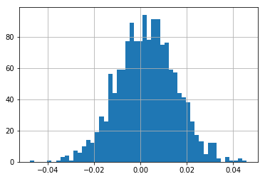

```python
one_year_mean = rets[0:252].mean()
one_year_stddev = rets[0:252].std()
print("one year mean: ", one_year_mean)
print("one year stddev: ", one_year_stddev)

random_draws_1yr = numpy.random.normal(one_year_mean, one_year_stddev, 1511)

hist(random_draws_1yr,50)
grid()
```

## 4.d

```
five year mean:  0.0008808372707065675
five year stddev:  0.013677817275170477
```

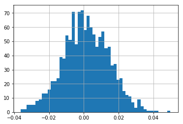

```python
five_year_mean = rets[0:252*5].mean()
five_year_stddev = rets[0:252*5].std()
print("five year mean: ", five_year_mean)
print("five year stddev: ", five_year_stddev)

random_draws_5yr = numpy.random.normal(one_year_mean, one_year_stddev, 252 * 5)

hist(random_draws_5yr, 50)
grid()
```

When comparing the two distributions, the smaller resolution yields a higher average. This is because the stock I chose is mostly positive. The smaller sample size means that the smaller distribution would be more shifted towards the positive return that is seen for the one year window.

## 4.e

```python
#Generate annualized return time series
annualized_rets = rets * 252.0
```

```
Blue: Simulated daily return
Orange: Annualized returns
```

[figure not shown]

```python
hist(random_draws_1yr, 50, alpha=0.5)
hist(annualized_rets, 50, alpha=0.5)
print("Blue: Simulated daily return")
print("Orange: Annualized returns")
show()
```

Annualizing the returns of daily stock scaled the stock prices to be outside of the typical daily range of the graph from 4c, as that graph deals with daily returns. Both graphs appeared to be normal, howevever overlaying yearly returns outscaled daily returns significantly.

## 4.f

```python
# Setup variables
n = 20
mu = mean_daily_ret
sigma = daily_stddev

# Calculate random variable inequality
prob = (-.1) / n
z_check_val = (prob - mu) / (sigma / sqrt(n))
```

```python
from scipy import stats

# Compute z score from z_check_val
probability = stats.norm.cdf(z_check_val)
print("probability: ", probability)
```

```
probability:  0.03562621377474326
```

## 4.g

```python
count_occurances = 0
for j in range(0, 100000):
    temp_sum = 0
    for i in range(0, 20):
        rand_index = random.randint(1, len(rets))
        temp_sum = temp_sum + rets[rand_index]
    if(temp_sum <= -0.10):
        count_occurances =  count_occurances + 1
print(count_occurances/100000)
```

```
0.02878
```

We see here that when we compare the raw probability distribution value to our manual calculation, we get a similar result. Since 100000 trials is significantly large, we are able to see this value come out appropriately. However, there is about a 1% difference between the values as the bootstrapping may or may not make use of actual outliers rather than simple means that the formula uses.